# Statistics for Data Science - Homework 3

#### Same group (TD subjects)

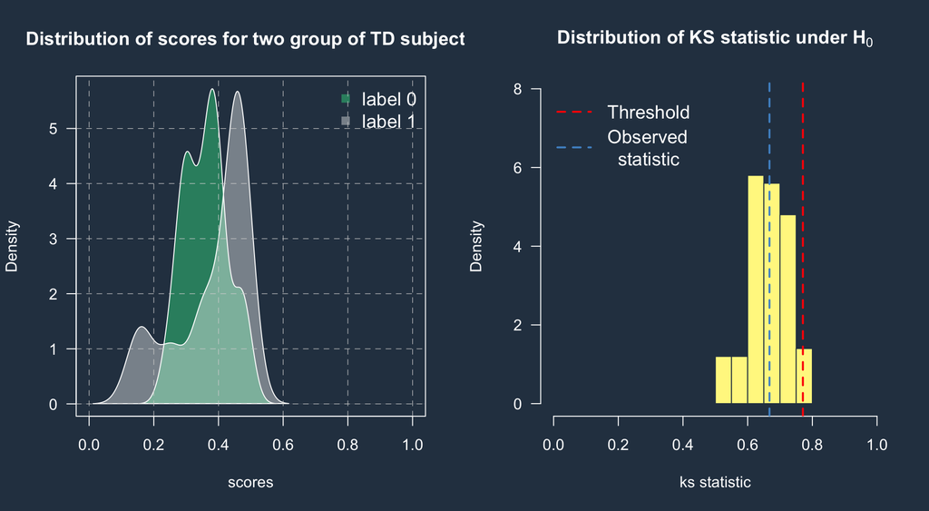

##### Comment

The first plot shows the two distributions of the Kolmogorov-Smirnov scores for both samples. The second one shows the distribution of the statistics under the null hypothesis. The red line is the quantile at level $1- \alpha = q_{\alpha}$ of the distribution, and the blue line is the observed value of the statistic we get with our data.

#### Perform the test with TD and ASD subjects respectively with the labels 0 and 1

[figure not shown]

```r
 dim(x_data)
u_2 <- as.matrix(x_data)
label <- c(rep(0, 50), rep(1, 43))

n0 <- 50
n1 <- 43

model_2 <- glmnet(
  x = u_2[, 1:(k - 1)],
  y = label,
  family = "gaussian",
  alpha = 0.1,
  maxit = 100
)
sc_2 <- predict(model_2, u_2[, 1:(k - 1)] , s = 0.7)
k2 <- ks.test(sc_2[1:50] , sc_2[51:93])$statistic

bb <-
  Friedman_procedure(
    P = 100,
    x_data = x_data[1:50, ],
    z_data = x_data[51:93, ],
    permut = T
  )
k2 < quantile(bb, 0.95)
```

##### Comment

The first plot shows the two distributions of the Kolmogorov-Smirnov scores for both samples. The second one shows the distribution of the statistics under the null hypothesis. The red line is the quantile at level $1- \alpha = q_{\alpha}$ of the distribution, and the blue line is the observed value of the statistic we get with our data.

Since the decision rule is to reject the null hypothesis if the observed value of Kolmogorov Smirnov statistics is greater than $q_{\alpha}$, we reject the null hypothesis. Data show enough evidence in order to reject the null hypothesis, we claim that the distribution of the scores of asd and td subjects are different.

#### Conclusion and final remark

In the case of interest we are dealing with a noisy and small set of data, and the higher the dimension the lower the information effectively available to resolve the difference and without a large enough amount of data, we fall into the curse of dimensionality problem, so to have a better and more consinstent performance of the test is worth to collect more data.